# Graphing in R: 101

For this tutorial, we’ll cover how to generate basic 2-dimensional plots in `R`  
To get started, we’ll load the `ggplot2` library. We’ll make use of the openly available `diamonds` dataset that imports with `ggplot2`.

```r
library(ggplot2)
```

Let’s take a quick look at the structure of this data.

```r
str(diamonds)
```

```
## tibble [53,940 × 10] (S3: tbl_df/tbl/data.frame)
##  $ carat  : num [1:53940] 0.23 0.21 0.23 0.29 0.31 0.24 0.24 0.26 0.22 0.23 ...
##  $ cut    : Ord.factor w/ 5 levels "Fair"<"Good"<..: 5 4 2 4 2 3 3 3 1 3 ...
##  $ color  : Ord.factor w/ 7 levels "D"<"E"<"F"<"G"<..: 2 2 2 6 7 7 6 5 2 5 ...
##  $ clarity: Ord.factor w/ 8 levels "I1"<"SI2"<"SI1"<..: 2 3 5 4 2 6 7 3 4 5 ...
##  $ depth  : num [1:53940] 61.5 59.8 56.9 62.4 63.3 62.8 62.3 61.9 65.1 59.4 ...
##  $ table  : num [1:53940] 55 61 65 58 58 57 57 55 61 61 ...
##  $ price  : int [1:53940] 326 326 327 334 335 336 336 337 337 338 ...
##  $ x      : num [1:53940] 3.95 3.89 4.05 4.2 4.34 3.94 3.95 4.07 3.87 4 ...
##  $ y      : num [1:53940] 3.98 3.84 4.07 4.23 4.35 3.96 3.98 4.11 3.78 4.05 ...
##  $ z      : num [1:53940] 2.43 2.31 2.31 2.63 2.75 2.48 2.47 2.53 2.49 2.39 ...
```

To see the description of the `diamonds` dataset, we can run:

```r
?diamonds
```

As we can see from the printout and from the description of the dataset, it contains information about `53,940` diamonds, and their qualities, such as their weight (coded `carat`), the quality of their cut (coded `cut`), their `price`, and so on.

Let’s say we want to explore the relationship between two of the variables, say `carat` and `price`. We can plot one of these variables along the $x$-axis of a “Cartesian” (i.e., coordinate) plane, and the other on the $y$-axis to discover the nature of that relationship.

# Plotting two variables in `base R`

In `base R`, we can use the in-built function `plot`. (Use `?plot` to read its description in more detail.) By default, the `plot` function will require at least two arguments: an `x` and `y` variable. These will be interpreted and displayed by `plot` as the $x$ and $y$ coordinates of each point. (For this reason, `plot` expects `x` and `y` to each be of the same length.)

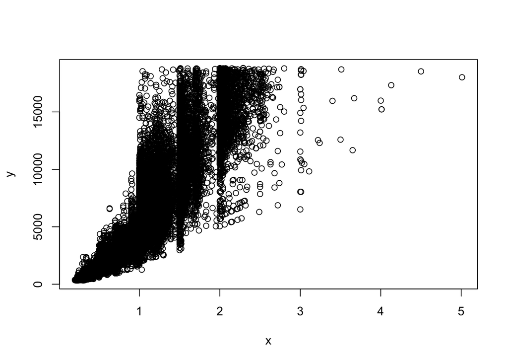

```r
# Let us assign carat to the variable called 'x', and price to 'y'
x <- diamonds$carat
y <- diamonds$price
plot(x, y)
```

```r
# Note that "x" and "y", as interpeted above by `plot()`
# are the values we stored in the two lines of code above.
```

This is called a scatterplot. It shows us the “bivariate” relationship between two variables by plotting, for each datapoint, the value of one variable along one axis, and the corresponding value of the other variable along the other axis. We can glean that if points with low values for one variable also have low values of the other variable, or if datapoints with high values of one variable have high values of the other variable as well, that the two variables are positively correlated. We see such a trend, among other things, from plotting `carat` and `price` here.

Now that we have gotten a cursory sense of how the two variables co-occur, let’s add a regression line to visualize the statistical relationship between them. To fit a regression in `R`, we can use the `lm` function, which will fit a ‘linear model’. (Use `?lm` to see a full description of the funciton.) Here we’ll use the formulae syntax in-built into `R`, as follows: `y ~ x`. Here, our $y$ variable is the `price` of the diamond, and we’ll predict it from `carat`, our $x$ variable.

```r
diamonds_model <- lm(y ~ x) # recall that we stored price and carat as 'y' and 'x'
# Or, equivalently: `diamonds_model <- lm(price ~ carat, data = diamonds)`
```

Now let’s add a line to visualize the relationship between the variables. The function we use to graph a regression line is `abline`. By default, `abline` must be called after an existing scatterplot is already drawn. This also means that you don’t need to re-generate a plot when you use it. `R` knows automatically that you want to draw your regression line overtop of the your existing scatterplot if you simply call `plot`, and then `abline`. To `abline`, we supply the model object that we fit using `lm`, and `abline` automatically converts it to a line.

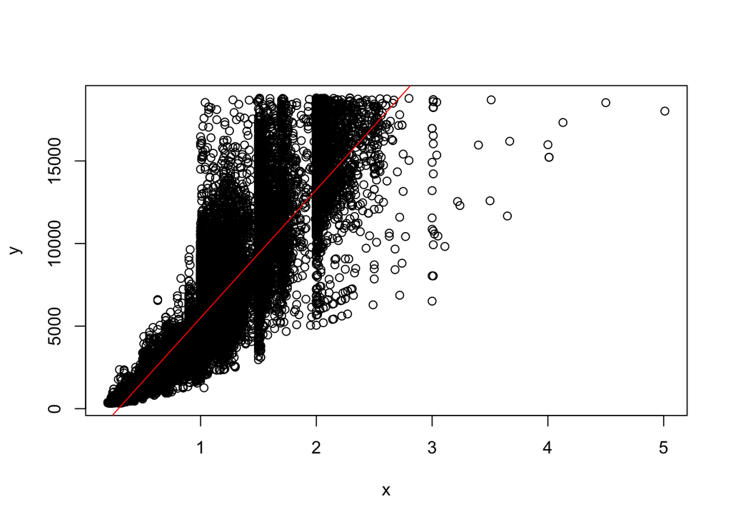

```r
# Here we re-generate the scatterplot:
plot(x = x, y = y)
abline(diamonds_model, col = 'red')
```

# Customizing the plots

As you may have noticed, we supplied an additional argument above: `col = 'red'`. `col` is an argument (or “parameter”) that the function `abline` recognizes, and which the user can specify the color of the line drawn by `abline`.

There are many other parameters that we can customize to make our graphs look publication ready! To see a list of all of the customizeable “graphical parameters”, you can run:

```r
?`graphical parameter`
```

We’ll start with the following, for just a quick overview:

1. `col`: we can supply a character string, such as ‘red’, or a number, such as 2 to specify the color for a (or all) point(s)
2. `pch`: we can supply 1, 2, 3, 4, up to 25 to change the shape of the points
3. `xlab`; `ylab`: these parameters can be used to set the labels for the x and y axes
4. `main`: supply a character string to `main` to set the title of the plot.
5. `cex`: this controls the size of the points, as well as text, such as axis labels, on the plot
6. `xlim`; `ylim`: Set the range of values spanning the x and y axes

For the `abline` function (and for `plot` depending on the `type` parameter) we can also change different qualities of the *line* that we plot. These can take the form of, but are not limited to, for example:

1. `lty`: change the type of line (e.g, dotted, dashed, solid, etc)
2. `lwd`: the thickness of the line

-Again, `col`, and other parameters can be applied as in `plot`

Let’s give it a whirl

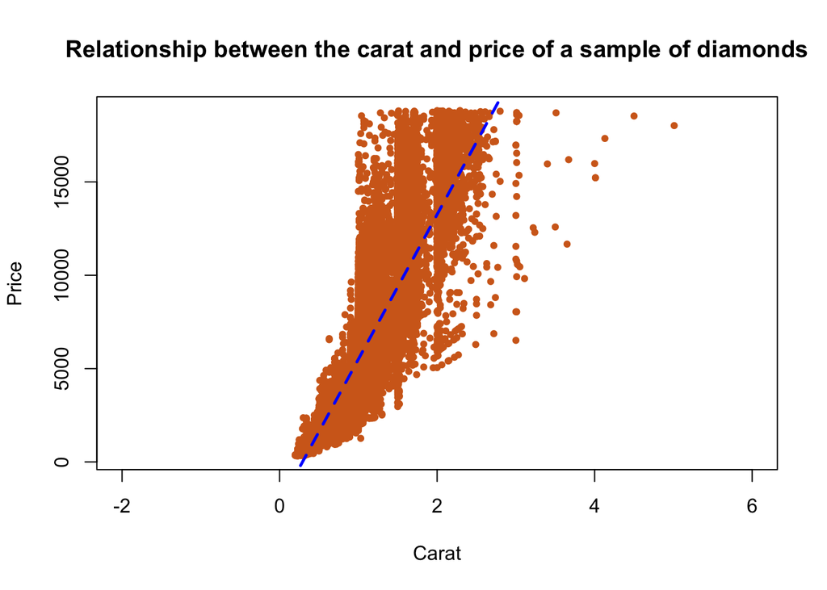

```r
plot(x, y,
     col = 'chocolate', # there are many in-built colors in R's palette!
     pch = 20,
     xlab = 'Carat',
     ylab = 'Price',
     main = 'Relationship between the carat and price of a sample of diamonds',
     xlim = c(-2, 6))
# And we'll add the regression line
abline(diamonds_model, col = 'blue', lty = 2, lwd = 2.4)
```

Bonus advanced aesthetics: Just as the `abline` function simply draws a line overtop an existing plot, you can command `R` to do this any number of times using the following method:

1. Generate any plot, such as the ones drawn above with `plot`
2. In the next line, run: `par(new = TRUE)` # or equivalently `par(new = T)`
3. Generate another plot, such as one using `plot`, and it will be superimposed
4. repeat any number of times

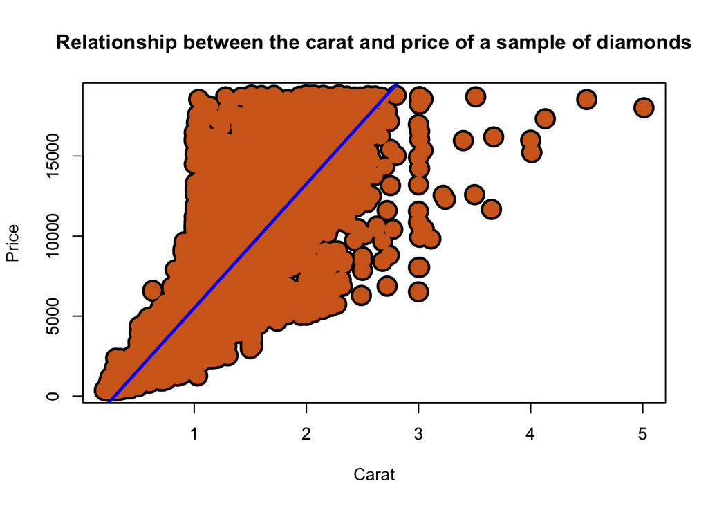

```r
plot(x, y,
     col = 'black', # there are many in-built colors in R's palette!
     pch = 20,
     cex = 4,
     xlab = 'Carat',
     ylab = 'Price',
     main = 'Relationship between the carat and price of a sample of diamonds')
# instruct R to draw the next plot on top of the existing:
par(new = T)
# Generate a new plot
plot(x, y,
     col = 'chocolate', # there are many in-built colors in R's palette!
     pch = 20,
     cex = 3,
     xlab = '', # we don't want, or need, to redraw the same axis label and title text
     ylab = '', # we don't want, or need, to redraw the same axis label and title text
     main = '') # we don't want, or need, to redraw the same axis label and title text
# And add the regression line as before
abline(diamonds_model, col = 'blue', lwd = 3)
```